# Reducing sugars report

Jovan Pavlović

4/23/2021

## Introduction(Benedicts test)

Benedict’s reagent is complex mixture of sodium carbonate, sodium citrate and copper(II) sulfate pentahydrate. The Benedict’s reagent is used for identifying reducing sugars(sugars that are capable of acting as a reducing agent which have free ketone or aldehyde groups; Mainly monosaccharide’s and some disaccharides). This is refered as Benedict’s test and it’s common method for testing presence of glucose in urine.

#### Principle of Benedict’s Test:

Reducing sugars(such as glucose) are capable of transferring hydrogens (electrons) to other compounds, a process called reduction. When reducing sugars are mixed with Benedict’s reagent and heated, a reduction reaction causes the Benedict’s reagent to change color. Color varies from blue to dark red, depending on concentration of sugar in solution.

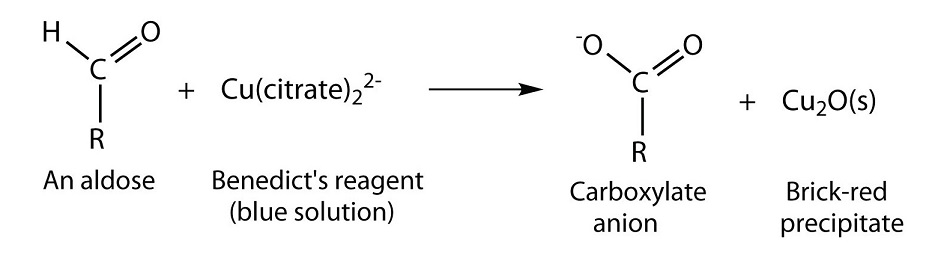

## Necessary hardware:

Spectophotometer

12 glass tubes

6 filter papers

## Procedure(Benedict’s test)

Firstly, we picked 2 tubes and added solution containing glucose in one and water in another (approximately 1 ml of each). Then we added same volume of Benedict’s reagent (approximately 2 ml) in both tubes and heated them in water bath for 5 min. on 80°C. At this point, we were able to notice that solution in tube where glucose was present changed from blue to dark red. This is caused by reduction of Copper (II) to Copper(I) ions and formation of Copper(I) oxyde which is insoluble in water and is precipitated out of solution

## Procedure(Quantitative test for reducing sugars)

We repeated Benedict’s test in 6 different tubes with same volumes of solutions that contain glucose, but with different concentrations of glucose.  
Concentrations of glucose:

- 0.05% in 1st tube
- 0.1% in 2nd tube
- 0.25% in 3rd tube
- 0.5% in 4th tube
- 1% in 5th tube
- unknown concentration in 6th tube

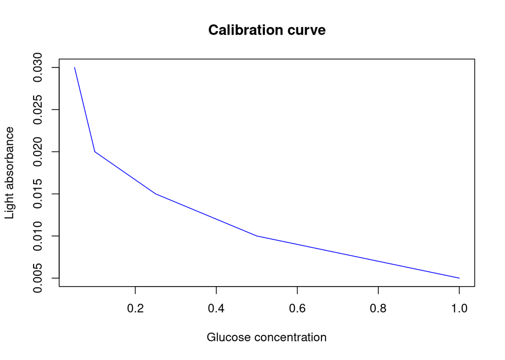

## Making calibration curve prediction using R

When a calibration curve is a straight-line, we represent it using the following mathematical equation:  
$y = \beta_0 + \beta_1x$  
where x is substance concetration and y is measured light absorbance. The constants $\beta_0$ and $\beta_1$ are, respectively, the calibration curve’s expected y-intercept and its expected slope. Because of uncertainty in our measurements, the best we can do is to estimate values for $\beta_1$ and $\beta_1$, which we represent as $b_0$ and $b_1$ The goal of a *linear regression* analysis is to determine the best estimates for $b_0$ and $b_1$. How we do this depends on the uncertainty in our measurements. More details about mathematical models of calibration curve prediction on this link

### Entering data and creating regression model

To begin, create objects that contain the concentration of known solutions and their corresponding absorbance.

```r
conc = c(0.05,0.1,0.25,0.5,1)
absorbance = c(0.03,0.02,0.015,0.01,0.005)
```

The command for a straight-line linear regression model is

```r
lm(x~y)
```

where y and x are the objects the objects our data. To access the results of the regression analysis, we assign them to an object using the following command

```r
model = lm(absorbance ~ conc)
```

To evaluate the results of a linear regression we need to examine the data and the regression line, and to review a statistical summary of the model. To examine our data and the regression line, we use the plot command,and abline command.

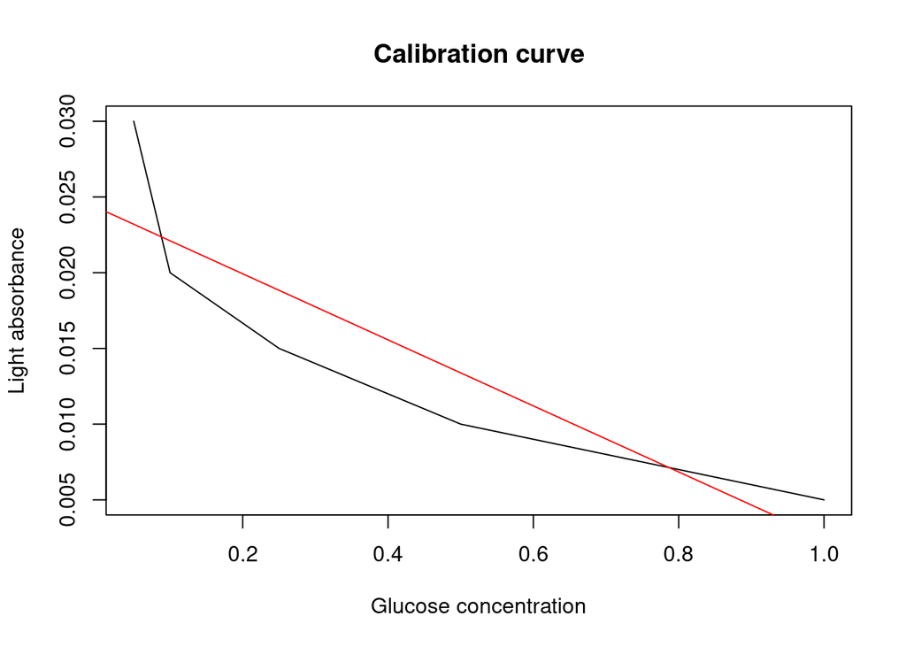

```r
plot(conc,absorbance,type = "l",main = "Calibration curve",xlab = "Glucose concentration", ylab = "Light absorbance")
abline(model,col = "red")
```

To review a statistical summary of the regression model, we use the summary command.

```r
summary(model)
```

```
##
## Call:
## lm(formula = absorbance ~ conc)
##
## Residuals:
##         1         2         3         4         5
##  0.006803 -0.002106 -0.003835 -0.003383  0.002521
##
## Coefficients:
##              Estimate Std. Error t value Pr(>|t|)
## (Intercept)  0.024287   0.003492   6.956   0.0061 **
## conc        -0.021808   0.006783  -3.215   0.0488 *
## ---
## Signif. codes:  0 '***' 0.001 '**' 0.01 '*' 0.05 '.' 0.1 ' ' 1
##
## Residual standard error: 0.005267 on 3 degrees of freedom
## Multiple R-squared:  0.7751, Adjusted R-squared:  0.7001
## F-statistic: 10.34 on 1 and 3 DF,  p-value: 0.04877
```

The first section of R’s summary of the regression model lists the residual errors. To examine a plot of the residual errors, use the following command

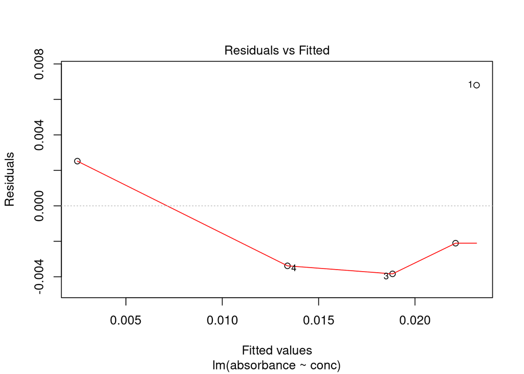

```r
plot(model,which = 1)
```

### Predicting the uncertainty in sample concentration by given absorbance

The command for predicting the uncertainty in sample concentration by given absorbance isn’t part of R’s standard installation. To use this command you need to install the “chemCal” package. Name of this command is *inverse.predict* and it’s used in following way

```r
library(chemCal)
prediction = inverse.predict(model,0.022)
```

As we see concentration estimated by this command is

```r
prediction$Prediction
```

```
## [1] 0.1048669
```

Finally we will plot resulting calibration curve

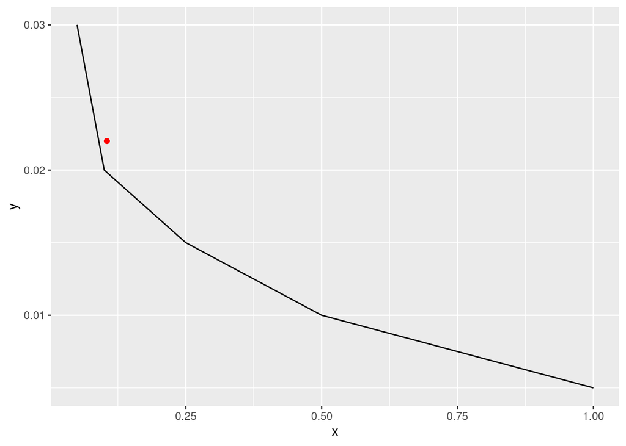

```r
library(ggplot2)
ggplot(df,aes(x=x,y=y))+geom_line() + geom_point(aes(y=0.022,x = prediction$Prediction),col = "red")
```

## Refernces

(Harvey 2020) (Wikipedia, n.d.)

Harvey, David. 2020. “Using Excel and r for a Linear Regression,” August. https://chem.libretexts.org/Bookshelves/Analytical_Chemistry/Book%3A_Analytical_Chemistry_2.1_(Harvey)/05%3A_Standardizing_Analytical_Methods/5.06%3A_Using_Excel_and_R_for_a_Linear_Regression#figure5.6.6.

Wikipedia. n.d. “Calibration Curve.” https://en.wikipedia.org/wiki/Calibration_curve.